# Modeling Malaria Infection & Immunity

A Primer

March 06, 2024

`~/Malaria Epidemiology/Modeling-Infection.Rmd`

$\otimes$ | hub | map | lectures | epi

## $\odot$

A Very Brief History, 1880-1969

**1880-1898**

After Laveran showed that malaria was caused by a parasite (1880), it was studied without knowing the mode of transmission. Then, Ronald Ross demonstrated that mosquitoes transmit malaria (1897), and the life-cycle of malaria parasites was described by Giovanni Battista Grassi (1898).

**1899-1911**

During the first decade of malaria vector control, Ronald Ross set the stage for the study of malaria transmission dynamics and control. Ross emphasized the importance of measuring malaria, made contributions to the measurement of malaria, and asked some very basic questions:

1. **What is the relationship between mosquito density and malaria prevalence?**
2. **How should we measure malaria?**

Ross developed a basic model, something like this one:

$$\frac{dX}{dt} = h (H-X) - r
X$$

where the prevalence of infection was $x = X/H$.

**1899-1949**

During the first 50 years of studying malaria epidemiology, most of the basic metrics to measure malaria were developed. Malariologists described most of the major patterns in malaria epidemiology and medical entomology.

**1950-1957**

George Macdonald published a quantitative synthesis, including:

1. A mathematical model of superinfection [1,2].
2. A mathematical formula for the EIR.
3. A formula for $R_0$

**1955-1969**

The Global Malaria Eradication Programme

## Models

### $\oplus$

- The SIS model (1908)
- The Garki Model (1974)
- Innovation
- A Work Horse

### The Garki Model

**1970-1974**

1. The Ross-Macdonald model was used to help design a malaria control trial in Kankiya District, northern Nigeria (1966-1969); the model predictions differed substantially from the trial results [3].
2. A new model was developed with malaria immunity and some other features, and it was used to design a new trial, conducted in Garki, Nigeria (1972-73) [4].

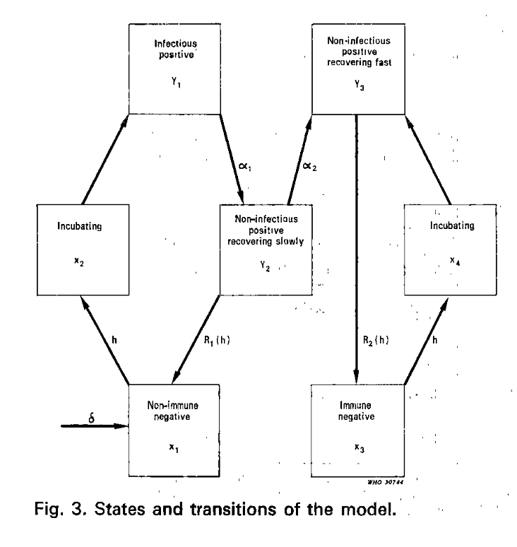

The Garki Model States and Transitions

### Innovation

Since 1974, there has been a lot of innovation in modeling human malaria infection and immunity. This is my quick summary of the world of mathematical models of malaria.

[figure not shown]

### Infection

#### $\oplus$

- The Duration of an Untreated Infection
- **MoI** - Superinfection and the Multiplicity of Infection (MoI)
- **AoI** - Age of Infection (AoI)
- **SoI** - Stage of Infection (SoI)

#### MoI

**Superinfection** and the **Multiplicity of Infection** (MoI)

**Queuing Models**

A compartmental model where each compartment describes the fraction of the population infected with $i$ distinct parasite clones.

In malaria, a commonly used queueing model is called **$M/M/\infty$**

**A Hybrid Model**

Let $m(t)$ denote the mean MoI in a population as it ages.

$$\frac{dm}{dt} = h - rm$$

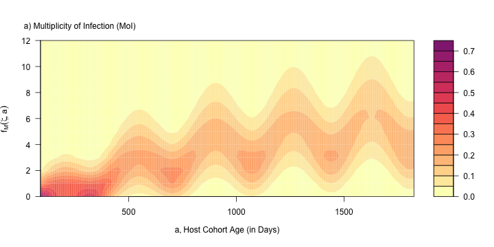

#### SoI

**Stage of Infection (SoI)**

Let $X$ denote the fraction of a population in each one of $n$ stages, $\mu_i$ the rate infections clear from a stage, $\theta_i$ the fraction that transition to a higher stage, and $\phi_i$ the fraction that transition to a lower stage. $\Theta$ is the transition matrix:

$$\begin{equation*}
\Theta =
\left[\begin{array}{ccccc}
\mu_1 +\theta_1 & -\phi_2 & \ldots & . \\
-\theta_1 & \mu_2 + \phi_2+\theta_2 & \ldots & . \\
. & -\theta_2 & \ldots & . \\
\vdots & \vdots & \ddots & \vdots \\
. & .& \ldots & -\phi_n \\
. & . & \ldots & \mu_n + \phi_n \\
\end{array}\right]
\end{equation*}$$

We assume that superinfection occurs, and that all new infections are in stage $1$. We let $h$ denote the force of infection. The dynamics of a cohort of simple infections (, without superinfection) is described by:

$$\begin{equation}
\frac{dX}{dt} = - \Theta \cdot X
\end{equation}$$

The matrix $\Theta$ describes a generalized phase-type distribution, and the matrix $\Theta^{-1}$ can be interpreted as a vector of residence times – the fraction of time a parasite infection in each stage would spend in every other stage, if there were no superinfection.

**With Superinfection**

To describe superinfection rates concisely, we let $u$ and $l$ denote strictly upper and lower triangular matrices of all 1’s. Overwriting superinfection redistributes infections at the rate $\mbox{diag}(hz) \left(u - l\right)\cdot X$. Uninfected individuals are infected at the rate $\mbox{diag}(hz) \left(I - u\right)\cdot X$, where $I$ is the identity matrix.

$$\begin{equation}
\frac{dX}{dt} = hz - \mbox{diag}(hz) \cdot l \cdot X - \Theta \cdot X
\end{equation}$$

The steady state is given by:

$$\begin{equation}
\bar X = \left( \mbox{diag}(hz) \cdot l + \Theta \right)^{-1} \cdot
hz
\end{equation}$$

$\left(\mbox{diag}(hz) \cdot l + \Theta\right) ^{-1}$, once again, describes a residence time from each stage to every other stage, but in this case, the residence times are affected by superinfection.

#### AoI

**Age of Infection (AoI)**

Also see `pf.memory`

Let $h$ denote the FoI, $m$ the mean MoI, $x$ the mean AoI, and $y$ the mean age of the youngest infection (AoY). In this model, prevalence is $p=1-e^{-m}.$ We can show that the dynamics of the MoI and the AoI are fully described by a simple system of equations.

$$\begin{equation}
\renewcommand{\arraystretch}{1.4}
\begin{array}{rl}
\frac{dm}{da} &= h - rm \\
\frac{dx}{da} &= 1 - x h / m \\
\frac{dy}{da} &= 1 - y h / p + \phi(r,m) x \\
\end{array}
\end{equation}$$

Using a probabilistic framework, we can translate information about exposure, infection, and the AoI into information about parasite densities and detection.

The distribution of the age of infection for the parasite clonal swarms and their density distributions; all the infections in a cohort of humans.

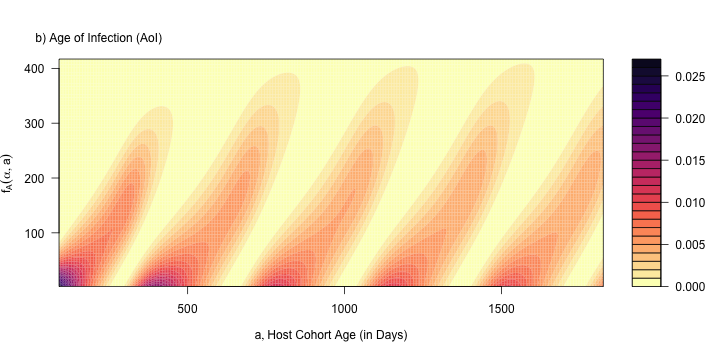

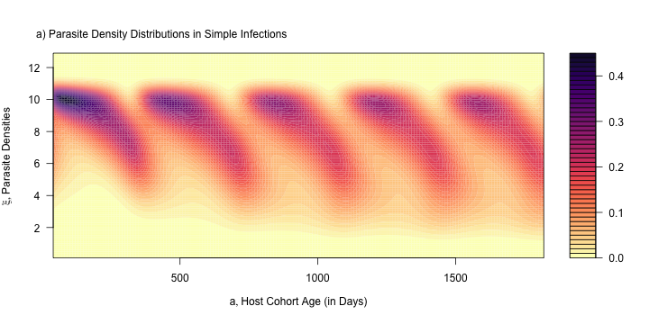

The distribution of the age of the youngest infection and parasite density distributions in a cohort of humans as they age.

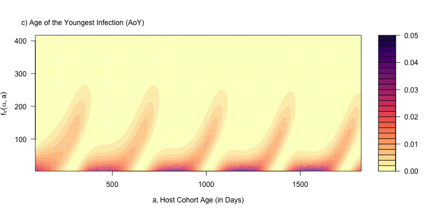

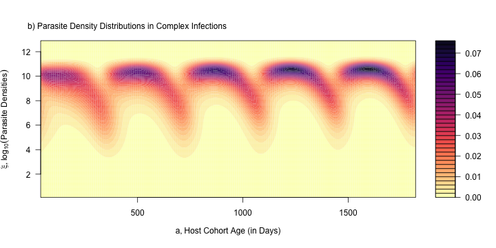

### Immunity

#### $\oplus$

- Age vs. prevalence
- Age vs. disease

#### Stage Structure

A model for the evolution of drug resistance with two immune stages [5].

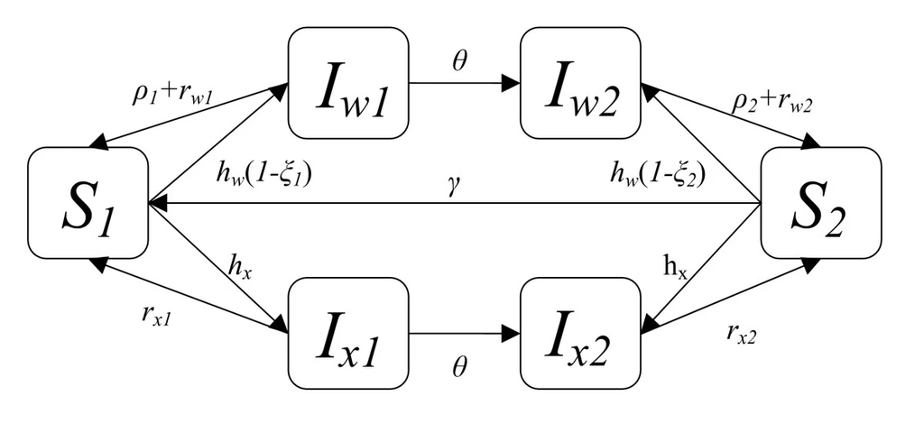

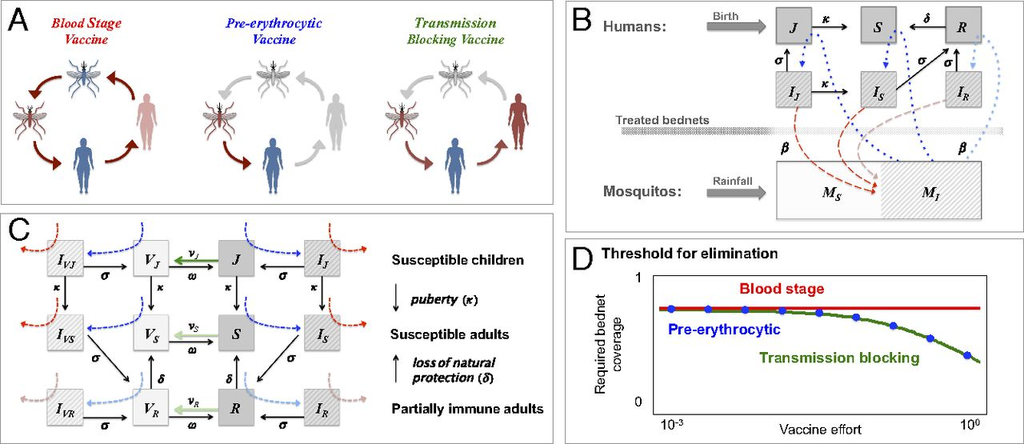

#### Tracking

Let $w$ be a class of variables that track exposure to malaria over various time scales:

$$dw/dt = F_w(h)$$

### Disease

- Severe malaria is caused by *virulent parasite types;* immunity is acquired early in life.
- Fever incidence / fever prevalence
- *Anemia*??

### Within-Host Modeling

… which leads to individual-based modeling.

## RAMP

### Skill Sets

Link to Skill Set

### PDG

**PDG** = **P**retty **D**amned **G**ood

Sooner or later, we have to come to grips with the need for mathematical models in malaria policy, but if we’re making decisions that affect people’s lives, we need to take the uncertainty very seriously. Over the past few decades, there has been a very serious discussion about how to deal with complexity. To start with, we must acknowledge an unavoidable fact:

> All models are wrong, some are useful.

This aphorism is attributed to a British statistician, George P. Box (see the Wikipedia page). In a 1997 book, he explained:

> All models are approximations. Assumptions, whether implied or clearly stated, are never exactly true. All models are wrong, but some models are useful. So the question you need to ask is not “Is the model true?” (it never is) but “Is the model good enough for this particular application?”

Our models don’t have to be perfect, but they need

1. A minimal *skill set;* including the ability to
2. Quantify and propagate uncertainty.

### Goals

What do we need from a mathematical model of malaria infection and immunity?

**Estimate the Burden of Malaria and the Averted Burden**

1. Burden
   - Severe disease including cerebral malaria, severe malaria anemia, …
   - Moderate disease - high fever
   - Mild disease (*e.g.* low / self-reported fever & malaise)
   - *Anemia*
2. Treatment & Chemoprotection
   - Averting disease
   - Reducing transmission
   - Adherence / partial treatment
3. Cohort Dynamics & Age Structure

**Fit Models to Data**

1. Exposure *vs.* Infection
   - Duration / Age of Infection
   - Superinfection
2. Immunity
   1. The relationship between exposure, age and infection prevalence
   2. Protection from disease
   3. Waning Immunity
3. Diagnostics and Detection

**Transmission Dynamics & Control**

1. Transmission / Infectiousness

## Work Horse

Work Horse

## References

1.

Macdonald G. The analysis of infection rates in diseases in which superinfection occurs. Trop Dis Bull. 1950;47: 907–915. Available: https://www.ncbi.nlm.nih.gov/pubmed/14798656

2.

Fine PEM. Superinfection - a problem in formulating a problem. Tropical Diseases Bulletin. 1975;75: 475–488.

3.

Nájera JA. A critical review of the field application of a mathematical model of malaria eradication. Bull World Health Organ. 1974;50: 449–457. Available: http://www.ncbi.nlm.nih.gov/entrez/query.fcgi?cmd=Retrieve&db=PubMed&dopt=Citation&list_uids=4156197

4.

Dietz K, Molineaux L, Thomas A. A malaria model tested in the African savannah. Bull Wld Hlth Org. 1974;50: 347–357. Available: http://www.ncbi.nlm.nih.gov/entrez/query.fcgi?cmd=Retrieve&db=PubMed&dopt=Citation&list_uids=4613512

5.

Klein EY, Smith DL, Boni MF, Laxminarayan R. Clinically immune hosts as a refuge for drug-sensitive malaria parasites. Malar J. 2008;7: 67. doi:10.1186/1475-2875-7-67